# Modelo epidemiológico de la CDMX

Max Orozco Carstensen

2023-10-12

Considera el modelo que usó la CDMX para moniterear al inicio de la pandemia de COVID-19 los casos, los hospitalizados y muertes en dicha entidad. El modelo se encuentra [acá](https://modelo.covid19.cdmx.gob.mx/modelo-epidemico)

1. **Explica el significado de cada ecuación: es decir, explica el significado de cada término y cada parámetro.**
- $R0$: Número reproductivo básico.
- $Dinfect$: Tiempo que un individuo es infeccioso.
- $Dincub$: Tiempo de incubación del virus.
- $Pgrave$: Tasa en la que los individuos enfermos son hospitalizados.
- $Dhosp$: Tiempo entre la aparición de síntomas y la hospitalización.
- $PICU$: Tasa de individuos que ingresan a terapia intensiva.
- $DLR$: Tiempo de hospitalización de casos leves.
- $DHR$: Tiempo entre la hospitalización de casos graves en terapia intensiva y recuperación.
- $PM$: Tasa de letalidad en población general.
- $DICU$: Tiempo entre hospitalización e ingreso a terapia intensiva.
- $DRICU$: Tiempo entre ingreso a terapia intensiva y recuperación.
- $DM$: Tiempo entre ingreso a terapia intensiva y deceso.

*Susceptibles:*

Afecta:

- $SI \frac {R0}{Dinfect}$ : Interacción entre susceptibles e infectados, dependiente del valor de R0 y el tiempo que un individuo es infeccioso.

*Expuestos:*

Favorece:

- $SI \frac {R0}{Dinfect}$ : Interacción entre susceptibles e infectados, dependiente del valor de R0 y el tiempo que un individuo es infeccioso.

Afecta:

- $E \frac{1}{Dincub}$ : Individuos expuestos que pasan a ser infecciosos, dependiendo del tiempo de incubación del virus.

*Infectados:*

Favorece:

- $E \frac{1}{Dincub}$ : Individuos expuestos que pasan a ser infecciosos, dependiendo del tiempo de incubación del virus.

Afecta:

- $I \frac{1}{Dinfect}$ : Individuos infectados que pasan a contagiados sintomáticos leves, dependiendo del tiempo que un individuo es infeccioso.

*Contagiados sintomáticos leves:*

Favorece:

- $(1 - Pgrave) \frac{1}{Dinfect} I$ : Individuos infectados que pasan a contagiados sintomáticos leves, dependiendo del tiempo que un individuo es infeccioso y la tasa de no hospitalización.

Afecta:

- $L \frac{1}{DRL}$ : Individuos contagiados sintomáticos leves que se recuperan, dependiendo del tiempo de hospitalización.

*Contagiados sintomáticos graves:*

Favorece:

Afecta:

- $G \frac{1}{Dhosp}$ : Individuos contagiados sintomáticos graves que son hospitalizados.

*Hospitalizados:*

Favorece:

- $G \frac{1}{Dhosp}$ : Individuos contagiados sintomáticos graves que son hospitalizados.

*Unidad de terapia intensiva:*

Afecta:

- $(1 - PM) \frac{1}{DRICU} ICU$: Individuos en terapia intensiva que se recuperan.
- $PM \frac{1}{DM} ICU$: Individuos en terapia intensiva que mueren.

*Recuperados:*

Favorece:

- $L \frac{1}{DRL}$ : Individuos contagiados sintomáticos leves que se recuperan, dependiendo del tiempo de hospitalización.
- $(1-PICU) \frac{1}{DRH} H$: Individuos contagiados sintomáticos graves hospitalizados que se recuperan.
- $(1 - PM) \frac{1}{DRICU} ICU$: Individuos en terapia intensiva que se recuperan.

*Muertos:*

Afecta:

- $PM \frac{1}{DM} ICU$: Individuos en terapia intensiva que mueren.
2. **¿La población se conserva?**

**3. Encuentra, si existe, el punto de equilibrio *free-disease***

El punto de equilibrio free-disease ocurriría si R0 fuera menor a 1, pues, en el sentido literal, un infectado no podría contagiar ni a 1 persona.

4. **Usa los parámetros de parámetros que sugieren y resuelve numéricamente el sistema de ecuaciones diferenciales. Asegurate que tu solución alcance un punto de equilibrio. Discute tu resultado.**

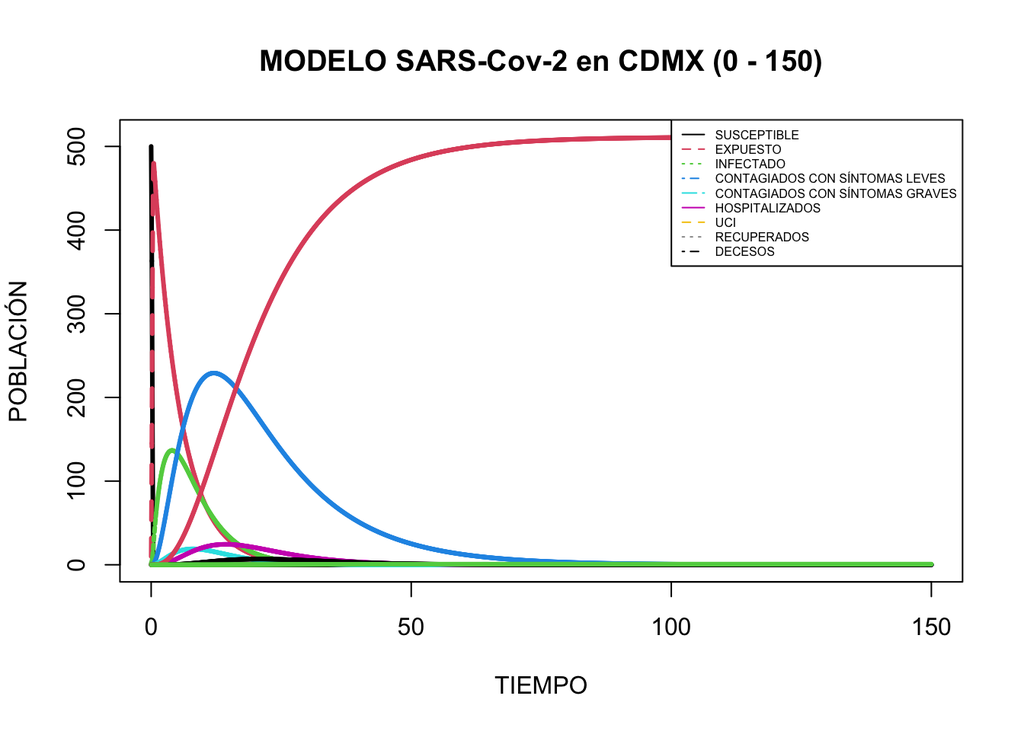

```r
library (deSolve)

SARS <- function (time, state, parameters) {
  with (as.list (c (state, parameters)), {
    dS <- - (R0 / Dinfect) * I * S
    dE <- (R0 / Dinfect) * I * S - (1 / Dincub) * E
    dI <- (1 / Dincub) * E - (1 / Dinfect) * I
    dL <- (1 - Pgrave) * (1 / Dinfect) * I - (1 / DRL) * L
    dG <- Pgrave * (1 / Dinfect) * I - (1 / Dhosp) * G
    dH <- (1 / Dhosp) * G - (1 - PICU) * (1 / DRH) * H - PICU * (1 / DICU) * H
    dICU <- PICU * (1 / DICU) * H - (1 - PM) * (1 / DRICU) * ICU - PM * (1 / DM) * ICU
    dR <- (1 / DRL) * L + (1 - PICU) * (1 / DRH) * H + (1 - PM) * (1 / DRICU) * ICU
    dM <- PM * (1 / DM) * ICU
    list (c (dS, dE, dI, dL, dG, dH, dICU, dR, dM))
  })
}

parameters <- c (Dinfect = 2.9, Dincub = 5.2, Pgrave = 0.1380, DRL = 14, Dhosp = 4, PICU = 0.05, DRH = 12, PM = 0.03, DICU = 1, DRICU = 7, DM = 8, R0 = 2.83)
initial_conditions <- c (S = 500, E = 10, I = 2, L = 0, G = 0, H = 0, ICU = 0, R = 0, M = 0)
time <- seq (0, 150, by = 0.001)
out <- ode (initial_conditions, time, SARS, parameters)

matplot (out [ , 1], out [ , 2 : 10], type = "l", xlab = "TIEMPO", ylab = "POBLACIÓN", main = "MODELO SARS-Cov-2 en CDMX (0 - 150)", lwd = 3)
legend ("topright", c ("SUSCEPTIBLE", "EXPUESTO", "INFECTADO", "CONTAGIADOS CON SÍNTOMAS LEVES", "CONTAGIADOS CON SÍNTOMAS GRAVES", "HOSPITALIZADOS", "UCI", "RECUPERADOS", "DECESOS"), col = 1 : 9, lty = 1 : 5, cex = 0.5)
```

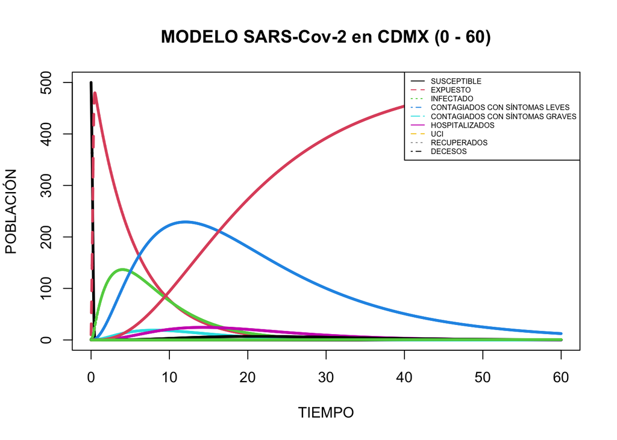

```r
parameters <- c (Dinfect = 2.9, Dincub = 5.2, Pgrave = 0.1380, DRL = 14, Dhosp = 4, PICU = 0.05, DRH = 12, PM = 0.03, DICU = 1, DRICU = 7, DM = 8, R0 = 2.83)
initial_conditions <- c (S = 500, E = 10, I = 2, L = 0, G = 0, H = 0, ICU = 0, R = 0, M = 0)
time <- seq (0, 60, by = 0.001)
out <- ode (initial_conditions, time, SARS, parameters)

matplot (out [ , 1], out [ , 2 : 10], type = "l", xlab = "TIEMPO", ylab = "POBLACIÓN", main = "MODELO SARS-Cov-2 en CDMX (0 - 60)", lwd = 3)
legend ("topright", c ("SUSCEPTIBLE", "EXPUESTO", "INFECTADO", "CONTAGIADOS CON SÍNTOMAS LEVES", "CONTAGIADOS CON SÍNTOMAS GRAVES", "HOSPITALIZADOS", "UCI", "RECUPERADOS", "DECESOS"), col = 1 : 9, lty = 1 : 5, cex = 0.5)
```

5. **¿Qué modificaciones se te ocurren que podrían implementarse para mejorar ese modelo?**